# Wing_Manuscript_Revisions2

Charles Thrift

2023-03-21

In this document, we analyze variation in wing morphologies between three species of *Halictus* and two populations of *Halictus tripartitus* using geometric morphometrics.

This document is the *third* version of this analysis, incorporating responses from multiple reviewers of our manuscript. Main changes include: removing ANOSIM and PCA tests and visualizations, and replacing with MANOVA and DAPC.

Necessary inputs for this script include: (1) TPS files containing plotted landmark data for each wing photograph or “occurrence” (2) CSV file containing all bee occurrence data, eg. all Hymenoptera from CCBER’s GBIF or Symbiota page. This is used to match the TPS wing occurrence with its proper species and population information.

##Load Packages

##Load Data ###Part One: TPS data The TPS data are in one file, which was created using tpsUtil32. Here, we read these data and specify a few parameters for the *readland.tps* function. There are no curves to be read (readcurves=FALSE), and any negative values for landmarks are negative in Cartesian space (negNA=FALSE). If negNA were true, the function would read any negative landmarks as a missing landmark (this is because while landmarking, if a character is obscured you can “skip” landmarks within the landmarking software. We do not include any specimens missing any landmarks in this analysis).

```r
#Read in the TPS data for all bee wing images
all_tps_data <- readland.tps("TPS_files/AppendedTPS_all_02sep22.TPS",
                             specID = c("imageID"), readcurves = FALSE,
                             warnmsg = TRUE,negNA = FALSE)
```

```
##
## No curves detected; all points appear to be fixed landmarks.
##
## Negative landmark coordinates have been identified and imported as such.
## If you want to treat them as NAs please set negNA = TRUE
```

###Part Two: Bee data Read bee data by first reading all Hymenoptera. After this chunk of code, all bee data is saved as **df1** and is ready to be merged with the TPS data.

```r
#need to have "beedata26jun22.csv" saved in working directory
all_CCBER_hymenoptera <- read_csv("beedata26jun22.csv")
#clean up data. Only keep relevant columns
df1 <- all_CCBER_hymenoptera
df1 <- df1[,c("catalogNumber", "family", "genus", "scientificName",
                   "decimalLatitude", "decimalLongitude", "eventDate",
                   "day", "month", "year", "identifiedBy", "sex", "startDayOfYear")]
#clean up data: prepare to match on catalogNumber
df1 <- df1 %>% separate(catalogNumber, c("UCSB", "number")) #issue btwn _ vs - in catalogNumber
df1 <- df1 %>% tidyr::unite('catalogNumber', sep = "_", c('UCSB','number')) #solving it by switching to _ from - in the downloaded Hymenoptera data
```

##Generalized Procrustes Analaysis (GPA) Run GPA on TPS data, to then generate coordinate data for each landmark on each specimen. In this code, we start with tps data and end with a CSV of coordinate data for each specimen. This can then be merged with the bee data generated above.

```r
all_tps_gpa <- gpagen(all_tps_data, PrinAxes = TRUE)
```

```
##
## Performing GPA
##
##
## Making projections... Finished!
```

```r
write.csv(all_tps_gpa$coords, "all_tps_21mar23.csv", row.names = TRUE)
write.csv(all_tps_gpa$Csize, "all_Csize_tps_21mar23.csv", row.names = TRUE)
```

##Merge Landmark Data with Bee Collection/Curation Data ###Adjust the Landmark Data to usable format Read in the landmark data. Read in the Csize data for each specimen. Adjust each.

```r
lmdata <- read.csv("all_tps_21mar23.csv") #read landmark data in
Csize <- read.csv("all_Csize_tps_21mar23.csv") #read Csize data in (note, not using it in this analysis)
Csize1 <- Csize
Csize2 <- setNames(cbind(rownames(Csize1), Csize1, row.names = NULL),
         c("number_delete", "specimenID", "Csize")) #add row names
Csize3 <- Csize2[,c(2:3)] #delete the first column (which is just numbering)
df_transpose = t(lmdata) #transpose the landmark data
df_transpose1 <- df_transpose
df_transpose1 <- df_transpose1[c(2:961),]
#Format of LM data is currently two rows per specimen
#with one row being X coordinate values and one row
#being Y coordinate values. Below, we split into two
#data frames and then stitch them back together to get
#18 different variables for the 9 landmarks
#(9 X coordinates and 9 Y coordinates)
lm1 <- df_transpose1
lmX <- lm1
lmY <- lm1
lmX1 <- lmX
lmX1 <- data.frame(lmX1)
lmX2 <- setNames(cbind(rownames(lmX1), lmX1, row.names = NULL),
                 c("name", "LM1x", "LM2x", "LM3x",
                   "LM4x", "LM5x", "LM6x", "LM7x", "LM8x", "LM9x"))
lmXonly <- lmX2[str_detect(lmX2$name, "X.UCSB"), ]
#repeat with Y
lmY1 <- lmY
lmY1 <- data.frame(lmY1)
lmY2 <- setNames(cbind(rownames(lmY1), lmY1, row.names = NULL),
                 c("name", "LM1y", "LM2y", "LM3y",
                   "LM4y", "LM5y", "LM6y", "LM7y", "LM8y", "LM9y"))
lmYonly <- lmY2[str_detect(lmY2$name, "Y.UCSB"), ]
lmXonly1 <- lmXonly
lmYonly1 <- lmYonly
lmXonly2 <- lmXonly1 %>%
    tidyr::separate(name,
                    c("X","UCSB", "barcode", "wing","species",
                      "location", "wingSide"), extra='drop') %>%
    tidyr::unite('catalogNumber', c('UCSB','barcode'))
#drop any wings that were Right instead of Left
lmXonly3 <- lmXonly2[lmXonly2$wingSide %in% c("ed", NA), ] #remove any "right" wings
lmXonly4 <- lmXonly3[lmXonly3$species %in% c("edited", "far",
                "lig", "tri"), ] #remove any "right" wings
lmXonly5 <- lmXonly4[,c(2,7:15)]
##now: lmXonly5 has x coordinate values for all 9 landmarks, and just the catalogNumber
###repeat for Y
lmYonly2 <- lmYonly1 %>%
    tidyr::separate(name,
                    c("Y","UCSB", "barcode", "wing","species",
                      "location", "wingSide"), extra='drop') %>%
    tidyr::unite('catalogNumber', c('UCSB','barcode'))
#drop any wings that were Right instead of Left
lmYonly3 <- lmYonly2[lmYonly2$wingSide %in% c("ed", NA), ] #remove any "right" wings
lmYonly4 <- lmYonly3[lmYonly3$species %in% c("edited", "far",
                "lig", "tri"), ] #remove any "right" wings
lmYonly5 <- lmYonly4[,c(2,7:15)]
########
#Now: unite the Y and X coordinate dataframes into just one
lm_both <- merge(lmXonly5, lmYonly5, by=c("catalogNumber"))
####Final step: add in the Csize column
Csize4 <- Csize3
Csize5 <- Csize4 %>%
    tidyr::separate(specimenID,
                    c("UCSB", "barcode", "wing","species",
                      "location", "wingSide"), extra='drop') %>%
    tidyr::unite('catalogNumber', c('UCSB','barcode'))
Csize6 <- Csize5[,c(1,6)]
lm_both_size <- merge(lm_both, Csize6, by=c("catalogNumber"))
####Done with landmark data. "lm" has each specimen and 18 variables for lm coordinates
####plus 1 variable for Csize
```

###Merge Landmark and Curation Data

```r
lm_data <- merge(lm_both_size, df1, by=c("catalogNumber"))
####removing some specimens from the analysis
allsets_data123 <- lm_data
##Need to drop the images with missing/obscured landmarks
allsets_data123 <- subset(allsets_data123, catalogNumber != "UCSB_IZC00041576")
allsets_data123 <- subset(allsets_data123, catalogNumber != "UCSB_IZC00041646")
allsets_data123 <- subset(allsets_data123, catalogNumber != "UCSB_IZC00037403")
allsets_data123 <- subset(allsets_data123, catalogNumber != "UCSB_IZC00037414")
allsets_data123 <- subset(allsets_data123, catalogNumber != "UCSB_IZC00038716")
# drop: poor photo quality
allsets_data123 <- subset(allsets_data123, catalogNumber != "UCSB_IZC00037491")
allsets_data123 <- subset(allsets_data123, catalogNumber != "UCSB_IZC00037465")
allsets_data123 <- subset(allsets_data123, catalogNumber != "UCSB_IZC00037432")
allsets_data123 <- subset(allsets_data123, catalogNumber != "UCSB_IZC00037425")
allsets_data123 <- subset(allsets_data123, catalogNumber != "UCSB_IZC00012006")
allsets_data123 <- subset(allsets_data123, catalogNumber != "UCSB_IZC00012259")
allsets_data123 <- subset(allsets_data123, catalogNumber != "UCSB_IZC00037414")
allsets_data123 <- subset(allsets_data123, catalogNumber != "UCSB_IZC00037403")
allsets_data123 <- subset(allsets_data123, catalogNumber != "UCSB_IZC00037397")
allsets_data123 <- subset(allsets_data123, catalogNumber != "UCSB_IZC00037386")
allsets_data123 <- subset(allsets_data123, catalogNumber != "UCSB_IZC00037356")
allsets_data123 <- subset(allsets_data123, catalogNumber != "UCSB_IZC00037336")
allsets_data123 <- subset(allsets_data123, catalogNumber != "UCSB_IZC00036708")
allsets_data123 <- subset(allsets_data123, catalogNumber != "UCSB_IZC00036688")
allsets_data123 <- subset(allsets_data123, catalogNumber != "UCSB_IZC00035322")
allsets_data123 <- subset(allsets_data123, catalogNumber != "UCSB_IZC00034772")
allsets_data123 <- subset(allsets_data123, catalogNumber != "UCSB_IZC00030903")
allsets_data123 <- subset(allsets_data123, catalogNumber != "UCSB_IZC00030503")
allsets_data123 <- subset(allsets_data123, catalogNumber != "UCSB_IZC00030428")
allsets_data123 <- subset(allsets_data123, catalogNumber != "UCSB_IZC00030379")
allsets_data123 <- subset(allsets_data123, catalogNumber != "UCSB_IZC00030327")
allsets_data123 <- subset(allsets_data123, catalogNumber != "UCSB_IZC00030289")
allsets_data123 <- subset(allsets_data123, catalogNumber != "UCSB_IZC00030048")
allsets_data123 <- subset(allsets_data123, catalogNumber != "UCSB_IZC00022211")
allsets_data123 <- subset(allsets_data123, catalogNumber != "UCSB_IZC00021402")
allsets_data123 <- subset(allsets_data123, catalogNumber != "UCSB_IZC00015171")
allsets_data123 <- subset(allsets_data123, catalogNumber != "UCSB_IZC00012463")
allsets_data123 <- subset(allsets_data123, catalogNumber != "UCSB_IZC00012424")
allsets_data123 <- subset(allsets_data123, catalogNumber != "UCSB_IZC00012342")
allsets_data123 <- subset(allsets_data123, catalogNumber != "UCSB_IZC00012277")
allsets_data123 <- subset(allsets_data123, catalogNumber != "UCSB_IZC00012056")
allsets_data123 <- subset(allsets_data123, catalogNumber != "UCSB_IZC00012049")
allsets_data123 <- subset(allsets_data123, catalogNumber != "UCSB_IZC00012026")
allsets_data123 <- subset(allsets_data123, catalogNumber != "UCSB_IZC00012018")
allsets_data123 <- subset(allsets_data123, catalogNumber != "UCSB_IZC00041576")
allsets_data123 <- subset(allsets_data123, catalogNumber != "UCSB_IZC00036237")
allsets_data123 <- subset(allsets_data123, catalogNumber != "UCSB_IZC00037365")
allsets_data123 <- subset(allsets_data123, catalogNumber != "UCSB_IZC00037381")
allsets_data123 <- subset(allsets_data123, catalogNumber != "UCSB_IZC00036773")
lm_data_clean <- allsets_data123
#remove 2 rows that have only Hymenoptera as their sci name
lm_data_clean <- subset(lm_data_clean, scientificName != "Hymenoptera")
```

##Summarizing Specimens

```r
lm <- lm_data_clean
lm$scientificName <- as.factor(lm$scientificName)
#rename the species to be easier to use than the whole author and year format
lm$species[lm$scientificName ==
             "Halictus tripartitus Cockerell, 1895"]<- "H. tripartitus"
lm$species[lm$scientificName ==
             "Halictus ligatus Say, 1837"]<- "H. ligatus"
lm$species[lm$scientificName ==
             "Halictus farinosus Smith, 1853"]<- "H. farinosus"
lm$species <- as.factor(lm$species)
summary(lm$species)
```

```
##   H. farinosus     H. ligatus H. tripartitus
##             44             75            307
```

```r
lm$location <- NA #store NA values first, then populate below with the right group
lm$location[lm$decimalLatitude <= 34.234 &
                 lm$decimalLatitude >= 33.86 &
                 lm$decimalLongitude >= -120.05 &
                 lm$decimalLongitude <= -119.45]<- "Santa Cruz Island"
lm$location[lm$decimalLatitude <= 36 &
                 lm$decimalLatitude >= 34.113887 &
                 lm$decimalLongitude >= -121 &
                 lm$decimalLongitude <= -116]<- "Mainland"
lm$location <- as.factor(lm$location)
summary(lm$location)
```

```
##          Mainland Santa Cruz Island              NA's
##               227               189                10
```

```r
lm <- subset(lm, location != "NA") #if it didn't get a population assigned, drop it from pop analysis
## Check count of species and locations
table(lm$species, lm$location)
```

```
##
##                  Mainland Santa Cruz Island
##   H. farinosus          3                40
##   H. ligatus           70                 0
##   H. tripartitus      154               149
```

## Create subset with equal numbers of specimens

Since there are different numbers of bees from each species group and population group, we randomly select the same number of bees from each group then combine them back into a single “species-level” data frame and “population-level” data frame.

```r
lm_standard <- lm
lm_ligatus <- subset(lm_standard, species == "H. ligatus")
lm_tripartitus <- subset(lm_standard, species == "H. tripartitus")
lm_farinosus <- subset(lm_standard, species == "H. farinosus")

set.seed(99)
lm_ligatus_standard <- lm_ligatus[sample(nrow(lm_ligatus),size = 43), ]
set.seed(99)
lm_tripartitus_standard <- lm_tripartitus[sample(nrow(lm_tripartitus),size = 43), ]
lm_farinosus_standard <- lm_farinosus #because this is the lowest value already

lm_standard_species <- rbind(lm_ligatus_standard,
                             lm_tripartitus_standard,
                             lm_farinosus_standard)

table(lm_standard_species$species, lm_standard_species$location)
```

```
##
##                  Mainland Santa Cruz Island
##   H. farinosus          3                40
##   H. ligatus           43                 0
##   H. tripartitus       24                19
```

```r
#now make a data frame with equal numbers of just h tripartitus by location
table(lm_tripartitus$location)
```

```
##
##          Mainland Santa Cruz Island
##               154               149
```

```r
tri_main <- subset(lm_tripartitus, location == "Mainland")
tri_island <- subset(lm_tripartitus, location == "Santa Cruz Island")

##based on table, need to reduce mainland down to 149, to match island
set.seed(99)
tri_main_standard <- tri_main[sample(nrow(tri_main),size = 149), ]
tri_island_standard <- tri_island #because this is the lowest value already
tri_data_standard <- rbind(tri_main_standard, tri_island_standard)
table(tri_data_standard$location)
```

```
##
##          Mainland Santa Cruz Island
##               149               149
```

## Make Table with Specimens Being Used

Here, we create a csv file that shows exactly which specimens are being included in the analyses below.

```r
#each row has a different bee
#columns: catalogNumber, species, location

specimens_by_species <- lm_standard_species #for species level
specimens_by_population <- tri_data_standard #for population level

specimens_by_species <- specimens_by_species[,c(1,33:34)]
specimens_by_population <- specimens_by_population[,c(1,33:34)]

write.csv(specimens_by_species, "specimens_by_species_21fmar23.csv", row.names = TRUE)
write.csv(specimens_by_population, "specimens_by_population_21mar23.csv", row.names = TRUE)
```

## MANOVA

Using MANOVA to test for difference between groups using the RRPP package.

```r
# MANOVA test with three species
manova_species <- lm_standard_species
manova_species <- manova_species[,c(2:19,33)] #drop catalog number and other non LM variables
manova_species_data <- manova_species[,c(1:18)] #drop species variable
manova_species_data <- as.matrix(manova_species_data) #as matrix

fit_species <- lm.rrpp(manova_species_data ~ species, SS.type = "I",
               data = manova_species, print.progress = FALSE) #run the linear model fit
fitm_species <- manova.update(fit_species, print.progress = FALSE, tol = 0) #run manova update
summary(fitm_species, test = "Pillai") #summarize with a manova table
```

```
##
## Linear Model fit with lm.rrpp
##
## Number of observations: 129
## Number of dependent variables: 18
## Data space dimensions: 18
## Residual covariance matrix rank: 14
## Sums of Squares and Cross-products: Type I
## Number of permutations: 1000
##
##            Df  Rand      Pillai  Z        Pr(>Pillai)
## species      2 Residuals 1.81658 12.92516 0.001
## Full.Model   2 Residuals 1.81658 12.92516 0.001
## Residuals  126
```

```r
# MANOVA for 2 populations
tri <- tri_data_standard

manova_tri <- tri
manova_tri <- manova_tri[,c(2:19,34)]
manova_tri$location <- as.factor(manova_tri$location)
manova_tri_data <- manova_tri[,c(1:18)] #removing the population column
manova_tri_data <- as.matrix(manova_tri_data)

fit <- lm.rrpp(manova_tri_data ~ location, SS.type = "I",
               data = manova_tri, print.progress = FALSE) #run the linear model fit
fitm <- manova.update(fit, print.progress = FALSE, tol = 0) #run the manova update
summary(fitm, test = "Pillai") #summarize with a manova table
```

```
##
## Linear Model fit with lm.rrpp
##
## Number of observations: 298
## Number of dependent variables: 18
## Data space dimensions: 18
## Residual covariance matrix rank: 14
## Sums of Squares and Cross-products: Type I
## Number of permutations: 1000
##
##            Df  Rand      Pillai    Z        Pr(>Pillai)
## location     1 Residuals 0.4247356 7.715231 0.001
## Full.Model   1 Residuals 0.4247356 7.715231 0.001
## Residuals  296
```

## DAPC

Rather than a PCA, we run a DAPC here to visualize difference between groups.

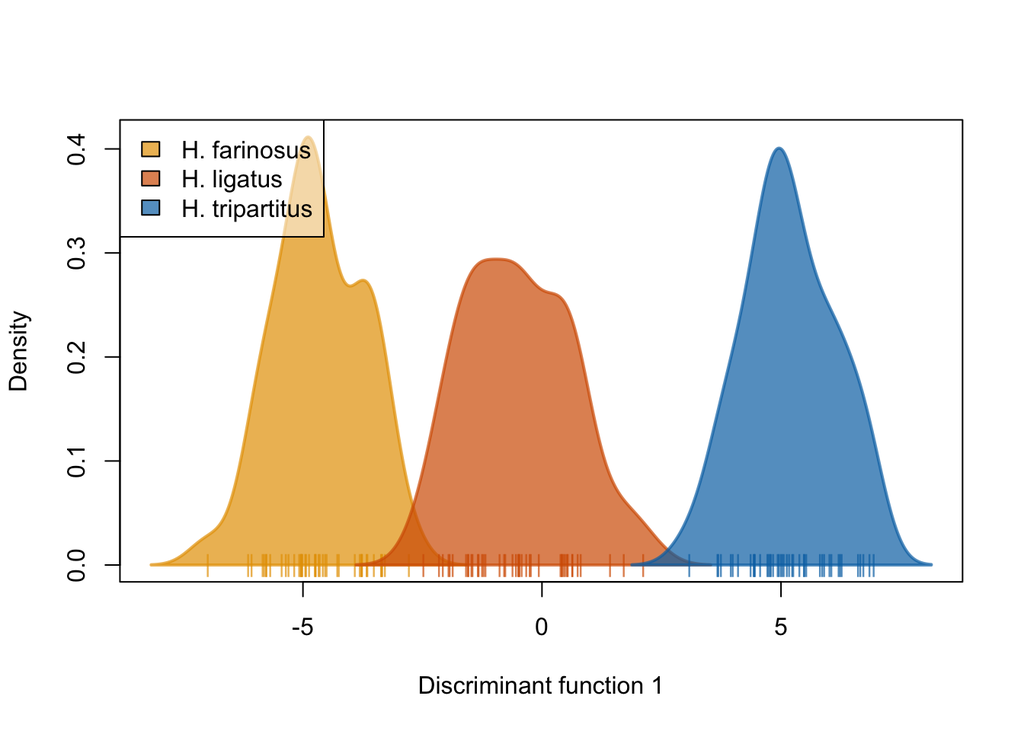

```r
species4 <- lm_standard_species
species <- species4[,c(2:19)] # Only preserves LM values

dapc_sp <- dapc(species,
                grp = species4$species,
                n.pca = 6,
                n.da = 10) #run DAPC on 3 species.

species_col <- c("#E69F00","#D55E00","#0072B2") #save color values for species
scatter(dapc_sp,1,1,bg="white",
        cstar=0, scree.pca=FALSE, posi.pca="topright",
        legend=TRUE, posi.leg="topleft", col = species_col) # plot w/ just one axis meaning just 1 DA
```

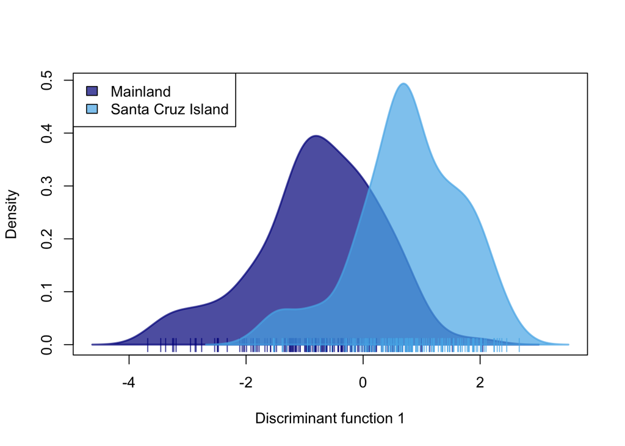

```r
# DAPC for 2 populations
pop4 <- tri_data_standard
population <- pop4[,c(2:19)] # Only preserves LM values

dapc_pop <- dapc(population,
                grp = pop4$location,
                n.pca = 9,
                n.da = 10) #run DAPC on 2 populations

population_col <- c("darkblue", "#56B4E9") #save colors for population

scatter(dapc_pop,
        bg="white",
        cstar=0, scree.pca=FALSE, posi.pca="topleft",
        legend=TRUE, posi.leg = "topleft",
        col = population_col) #plot the two populations
```

## Cross-validation using DAPC

Assign “unknown” bees to the correct group, and test for % accuracy.

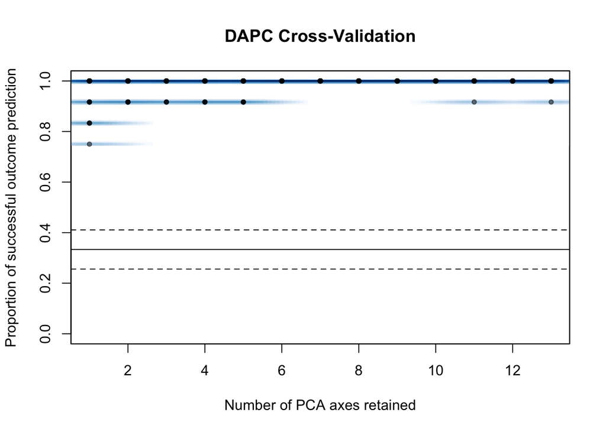

```r
species5 <- species4[,c(2:19,33)] #only save LM values and species variables
grp1 <- species5$species #assign groups to be the species variable
species6 <- species5[,c(1:18)] #only save LM values for analysis
xval_sp <- xvalDapc(species6, grp1, n.pca.max = 300, n.da = NULL,
                 training.set = 0.9,
                 result = c("groupMean", "overall"),
                 center = TRUE, scale = FALSE,
                 n.pca = NULL, n.rep = 30, xval.plot = TRUE) #run cross validation
```

```r
xval_sp$`Number of PCs Achieving Highest Mean Success` #which number of PCs retained has highest accuracy?
```

```
## [1] "6"
```

```r
xval_sp$`Mean Successful Assignment by Number of PCs of PCA` #what is accuracy at various PCs retained?
```

```
##         1         2         3         4         5         6         7         8
## 0.9638889 0.9861111 0.9916667 0.9888889 0.9888889 1.0000000 1.0000000 1.0000000
##         9        10        11        12        13
## 1.0000000 1.0000000 0.9972222 1.0000000 0.9972222
```

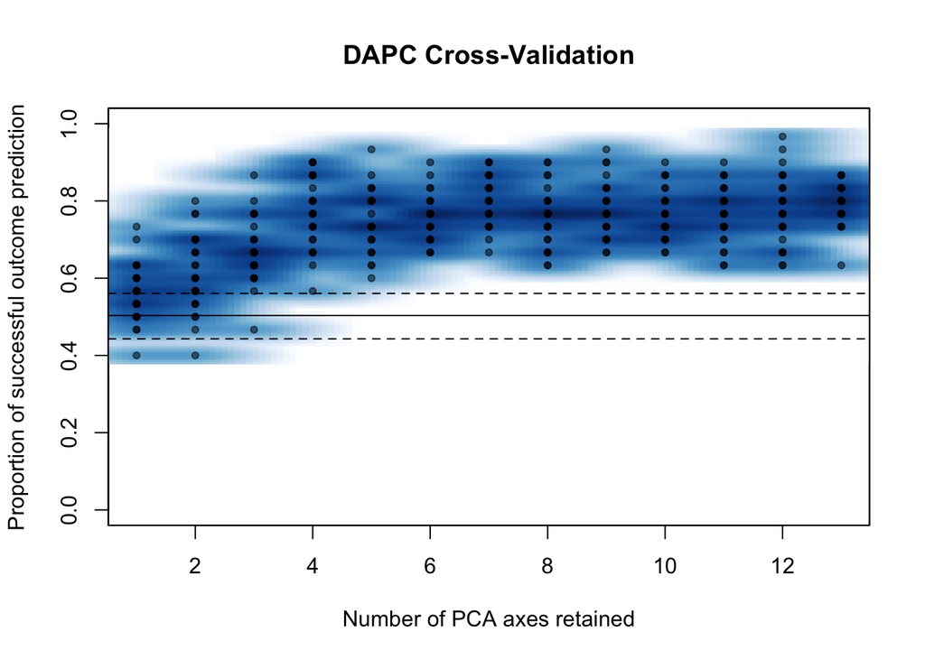

```r
#### NOW, repeat with the two populations instead
pop5 <- pop4[,c(2:19,34)] #same process: only save LM and population variables
grp2 <- pop5$location #assign grouping to be population variable
pop6 <- pop5[,c(1:18)] #only preserve LM values

xval_pop <- xvalDapc(pop6, grp2, n.pca.max = 300, n.da = NULL,
                 training.set = 0.9,
                 result = c("groupMean","overall"),
                 center = TRUE, scale = FALSE,
                 n.pca = NULL, n.rep = 30, xval.plot = TRUE) #run cross validation
```

```r
xval_pop$`Number of PCs Achieving Highest Mean Success`#which number of PCs retained has highest accuracy?
```

```
## [1] "7"
```

```r
xval_pop$`Mean Successful Assignment by Number of PCs of PCA`#what is accuracy at various PCs retained?
```

```
##         1         2         3         4         5         6         7         8
## 0.5644444 0.6166667 0.6711111 0.7700000 0.7500000 0.7533333 0.8033333 0.7577778
##         9        10        11        12        13
## 0.7766667 0.7655556 0.7700000 0.7766667 0.7944444
```